# P&S-2022: Lab assignment 2

Bohdan Zasymovych, Matseliukh Maksym, Mykolaichuk Nazar

### Work breakdown:

- Bohdan Zasymovych: Task 1, Task 4
- Matseliukh Maksym: Task 2
- Mykolaichuk Nazar: Task 3

## General comments and instructions

- Complete solution will give you **4 points** (working code with explanations + oral defense). Submission deadline **November 1, 2023, 22:00**
- The report must be prepared as an *R notebook*; you must submit to **cms** both the source *R notebook* **and** the generated html file
- At the beginning of the notebook, provide a work-breakdown structure estimating efforts of each team member
- For each task, include
  - problem formulation and discussion (what is a reasonable answer to discuss);
  - the corresponding $\mathbf{R}$ code with comments (usually it is just a couple of lines long);
  - the statistics obtained (like sample mean or anything else you use to complete the task) as well as histograms etc to illustrate your findings;
  - justification of your solution (e.g. refer to the corresponding theorems from probability theory);
  - conclusions (e.g. how reliable your answer is, does it agree with common sense expectations etc)
- The **team id number** referred to in tasks is the **two-digit** ordinal number of your team on the list. Include the line **set.seed(team id number)** at the beginning of your code to make your calculations reproducible. Also observe that the answers **do** depend on this number!
- Take into account that not complying with these instructions may result in point deduction regardless of whether or not your implementation is correct.

```r
id <- 5
set.seed(id)
```

### Task 1

#### In this task, we discuss the $[7,4]$ Hamming code and investigate its reliability. That coding system can correct single errors in the transmission of $4$-bit messages and proceeds as follows:

- given a message $\mathbf{m} = (a_1 a_2 a_3 a_4)$, we first encode it to a $7$-bit *codeword* $\mathbf{c} = \mathbf{m}G = (x_1 x_2 x_3 x_4 x_5 x_6 x_7)$, where $G$ is a $4\times 7$ *generator* matrix
- the codeword $\mathbf{c}$ is transmitted, and $\mathbf{r}$ is the received message $\mathbf{r}$ is checked for errors by calculating the *syndrome vector* $\mathbf{z} := \mathbf{r} H$, for a $7 \times 3$ *parity-check* matrix $H$
- if a single error has occurred in $\mathbf{r}$, then the binary $\mathbf{z} = (z_1 z_2 z_3)$ identifies the wrong bit no. $z_1 + 2 z_2 + 4z_3$; thus $(0 0 0)$ shows there was no error (or more than one), while $(1 1 0 )$ means the third bit (or more than one) got corrupted
- if the error was identified, then we flip the corresponding bit in $\mathbf{r}$ to get the corrected $\mathbf{r}^* = (r_1 r_2 r_3 r_4 r_5 r_6 r_7)$;
- the decoded message is then $\mathbf{m}^*:= (r_3r_5r_6r_7)$.

#### The **generator** matrix $G$ and the **parity-check** matrix $H$ are given by

$$G :=
\begin{pmatrix}
1 & 1 & 1 & 0 & 0 & 0 & 0 \\
1 & 0 & 0 & 1 & 1 & 0 & 0 \\
0 & 1 & 0 & 1 & 0 & 1 & 0 \\
1 & 1 & 0 & 1 & 0 & 0 & 1 \\
\end{pmatrix},
\qquad
H^\top := \begin{pmatrix}
1 & 0 & 1 & 0 & 1 & 0 & 1 \\
0 & 1 & 1 & 0 & 0 & 1 & 1 \\
0 & 0 & 0 & 1 & 1 & 1 & 1
\end{pmatrix}$$

#### Assume that each bit in the transmission $\mathbf{c} \mapsto \mathbf{r}$ gets corrupted independently of the others with probability $p = \mathtt{id}/100$, where $\mathtt{id}$ is your team number. Your task is the following one.

1. Simulate the encoding-transmission-decoding process $N$ times and find the estimate $\hat p$ of the probability $p^*$ of correct transmission of a single message $\mathbf{m}$. Comment why, for large $N$, $\hat p$ is expected to be close to $p^*$.
2. By estimating the standard deviation of the corresponding indicator of success by the standard error of your sample and using the CLT, predict the interval $(p^*-\varepsilon, p^* + \varepsilon)$, in which the estimate $\hat p$ falls with probability at least $0.95$.
3. What choice of $N$ guarantees that $\varepsilon \le 0.03$?
4. Draw the histogram of the number $k = 0,1,2,3,4$ of errors while transmitting a $4$-digit binary message. Do you think it is one of the known distributions?

#### You can (but do not have to) use the chunks we prepared for you

#### First, we set the **id** of the team and define the probability $p$ and the generator and parity-check matrices $G$ and $H$

```r
p <- id/100
# matrices G and H
G <- matrix(c(1, 1, 1, 0, 0, 0, 0,
        1, 0, 0, 1, 1, 0, 0,
        0, 1, 0, 1, 0, 1, 0,
        1, 1, 0, 1, 0, 0, 1), nrow = 4, byrow = TRUE)
H <- t(matrix(c(1, 0, 1, 0, 1, 0, 1,
        0, 1, 1, 0, 0, 1, 1,
        0, 0, 0, 1, 1, 1, 1), nrow = 3, byrow = TRUE))
cat("The matrix G is: \n")
```

```
## The matrix G is:
```

```r
G
```

```
##      [,1] [,2] [,3] [,4] [,5] [,6] [,7]
## [1,]    1    1    1    0    0    0    0
## [2,]    1    0    0    1    1    0    0
## [3,]    0    1    0    1    0    1    0
## [4,]    1    1    0    1    0    0    1
```

```r
cat("The matrix H is: \n")
```

```
## The matrix H is:
```

```r
H
```

```
##      [,1] [,2] [,3]
## [1,]    1    0    0
## [2,]    0    1    0
## [3,]    1    1    0
## [4,]    0    0    1
## [5,]    1    0    1
## [6,]    0    1    1
## [7,]    1    1    1
```

```r
cat("The product GH must be zero: \n")
```

```
## The product GH must be zero:
```

```r
(G%*%H) %%2
```

```
##      [,1] [,2] [,3]
## [1,]    0    0    0
## [2,]    0    0    0
## [3,]    0    0    0
## [4,]    0    0    0
```

```r
encode <- function(m) {
  return(m %*% G %% 2)
}

apply_errors <- function(m, e) {
  return((m + e) %% 2)
}

decode <- function(m) {
  decode_row <- function(row) {
    s <- (row %*% H) %% 2
    n <- 3
    dm <- sum(s * (2^(0:(n-1))))
    if (dm != 0) {
      row[dm] <- 1 - row[dm]  # flip bit
    }
    return(row[c(3, 5, 6, 7)])
  }
    return(t(apply(m, 1, decode_row)))
}

m <- matrix(c(0, 1, 0, 1), nrow = 1)
e <- matrix(c(0, 0, 0, 1, 0, 0, 0), nrow = 1)
c <- encode(m)
ec <- apply_errors(c, e)
d <- decode(ec)
cat("Initial message: ", m, "\n")
```

```
## Initial message:  0 1 0 1
```

```r
cat("Encoded message: ", c, "\n")
```

```
## Encoded message:  0 1 0 0 1 0 1
```

```r
cat("Encoded message after errors were applied: ", ec, "\n")
```

```
## Encoded message after errors were applied:  0 1 0 1 1 0 1
```

```r
cat("Decoded message: ", d, "\n")
```

```
## Decoded message:  0 1 0 1
```

```r
message_generator <- function(N) {
  matrix(sample(c(0,1), 4*N, replace = TRUE), nrow = N)
}

error_generator <- function(N) {
  matrix(sample(c(0,1), 7*N, replace = TRUE, prob = c(1-p, p)), nrow = N)
}
```

The next steps include detecting the errors in the received messages, correcting them, and then decoding the obtained messages. After this, you can continue with calculating all the quantities of interest

1. Simulate the encoding-transmission-decoding process N times and find the estimate $\hat{p}$ of the probability $p∗$ of correct transmission of a single message m. Comment why, for large N , $\hat{p}$ is expected to be close to $p∗$

```r
N <- 5000000

messages <- message_generator(N) # Generate N messages
codewords <- encode(messages) # Encode messages
errors <- error_generator(N) # Generate errors
received <- apply_errors(codewords, errors) # Apply errors to get received messages with errors
decoded_messages <- decode(received) # Decode messages
```

```r
incorrectly_decoded_messages <- N-sum(apply(xor(messages, decoded_messages), 1, any))
p_hat = incorrectly_decoded_messages/N
print(p_hat)
```

```
## [1] 0.955781
```

Let each transmission of a message be a Bernoulli trial, where
$$X_i =
\begin{cases}
1 & \text{if the $i$-th message is decoded correctly,} \\
0 & \text{otherwise.}
\end{cases}$$
All random variables $X_i$ is independent and identically distributed.

Let $(x_1, x_2, ... , x_N)$ be realization of $(X_1, X_2, ... , X_N)$, then $\hat{p}$ is estimated as $\hat{p}=\frac{x_1 + ... + x_N}{N}$ for $N$ independent transitions.

Then the true probability of the correct decoding is $p* = E(X_i)$

By the strong law of large the sample mean of i.i.d. random variables converges almost surely to the expected value as $N \to \infty$

$$\hat{p} = \frac{1}{N} \sum_{i=1}^{N} X_i \xrightarrow{a.s.}
\mathbb{E}[X_i] = p^*.$$

2. By estimating the standard deviation of the corresponding indicator of success by the standard error of your sample and using the CLT, find the half-length $ε$ of the confidence interval $(\hat{p} − ε, \hat{p} + ε)$, which contains the true value $p∗$ with probability at least $0.95$. What choice of N guarantees that $ε \le 0.03$?

Let $X_1, \dots, X_N$ be independent Bernoulli indicators of success with
$$\mathbb{P}(X_i = 1) = 1-p^*, \quad \mathbb{P}(X_i = 0) = p^*.$$

$$\mu=E(x_i)=1-p^*\\
\sigma^2 = E(X_i^2)-E(X_i)^2=p^*(1-p^*)$$
The sample mean is
$$\hat{p} = \frac{1}{N}\sum_{i=1}^{N} X_i.$$

By the Central Limit Theorem, for large $N$,
$$\hat{p} \sim \mathcal{N}\Big(\mu, \sigma^2\Big) \Rightarrow \hat{p} \sim
\mathcal{N}\Big(p^*, \frac{p^*(1-p^*)}{N}\Big)$$
A $95\%$ confidence interval is
$$(\hat{p} - z_{0.975} \cdot \mathrm{SE}(\hat{p}); \; \hat{p} + z_{0.975}
\cdot \mathrm{SE}(\hat{p}))$$
$z_{0.975}$ is chosen because in the standard normal distribution 95% of area under curve is between and $x=z_{0.975}$

where the standard error is estimated by
$$\mathrm{SE}(\hat{p}) \approx \sqrt{\frac{\hat{p}(1-\hat{p})}{N}}, \quad
z_{0.975} \approx 1.96.$$
From this $\varepsilon$ is equal to
$$\varepsilon = z_{0.975} \sqrt{\frac{\hat{p}(1-\hat{p})}{N}}.$$

To guarantee $\varepsilon \le 0.03$, we need to solve solve for $N$:
$$N \ge \frac{\hat{p}(1-\hat{p})}{(\varepsilon / z_{0.975})^2}.$$
To guarantee that $N$ is greater or equal we need to use maximum possible value for $\hat{p} (1-\hat{p})$ which is $0.25$ at point $0.5$ (can be found by finding derivative and solving equation where it is equal to 0). By plugging $\varepsilon=0.03$, $z_{0.975} \approx 1.96$ (from table) and $\hat{p}(1-\hat{p}) \le 0.25$, we get
$$N \ge \frac{0.25}{(0.03/1.96)^2} \approx 1067.$$

3. Draw the histogram of the number k = 0, 1, 2, 3, 4 of errors while transmitting a 4-digit binary message. Do you think the random variable that counts the number of wrong bits in a decoded message has one of the known distributions? Justify your answer.

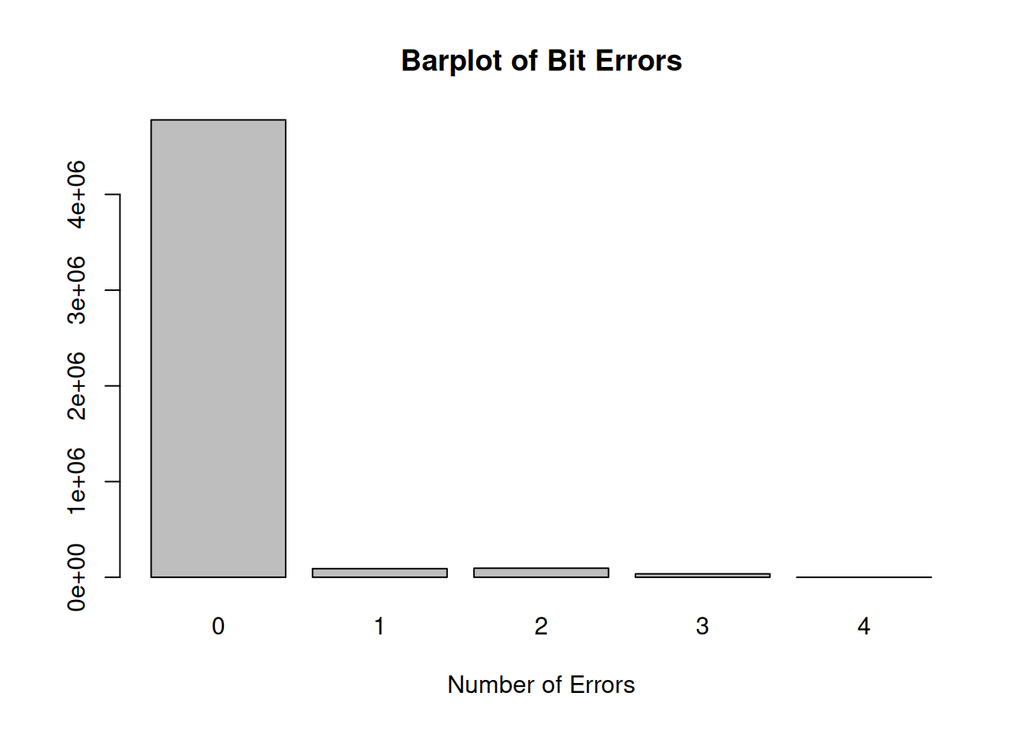

```r
number_of_errors <- apply(xor(messages, decoded_messages), 1, sum)

# Normal barplot
barplot(table(number_of_errors),
        main = "Barplot of Bit Errors",
        xlab = "Number of Errors")
```

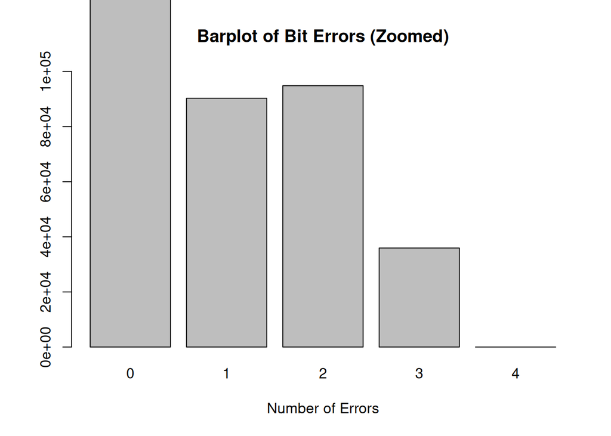

```r
# Zoomed barplot
barplot(table(number_of_errors),
        main = "Barplot of Bit Errors (Zoomed)",
        xlab = "Number of Errors",
        ylim = c(0, 100000))
```

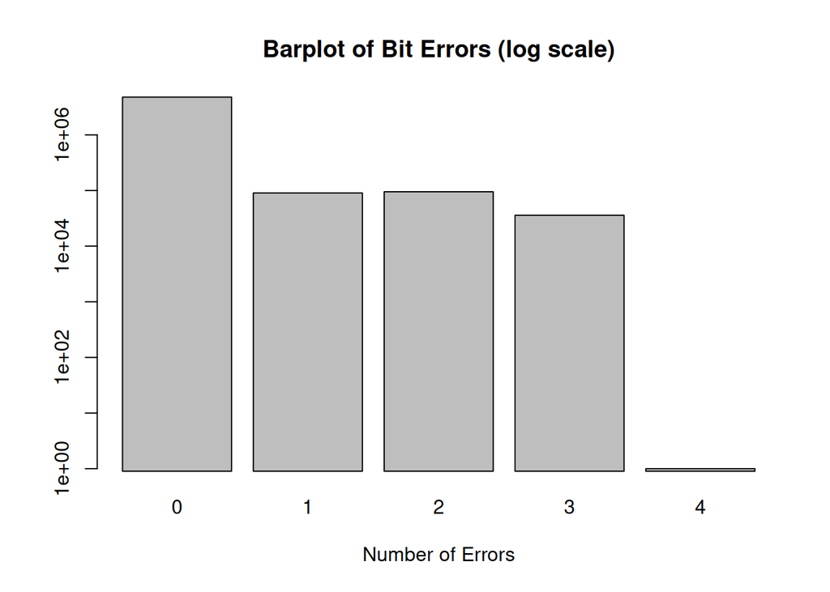

```r
# Logarithmically scaled barplot
barplot(table(number_of_errors),
        main = "Barplot of Bit Errors (log scale)",
        xlab = "Number of Errors",
        log="y")
```

```r
print(table(number_of_errors))
```

```
## number_of_errors
##       0       1       2       3       4
## 4778905   90298   94854   35942       1
```

In this task number of messages with 4 errors is only one, because probability of such case is extremely low.

I don’t think it is one of the known distributions because the number of errors in the decoded message depends on both the errors occurring during transmission and the logic of correction. Also, not only the number of flipped bits impacts the number of errors, but also the positions of the flipped bits. The number of errors during transmission follows a Binomial distribution with parameters $7$ and $p$ ($B(7,\,p)$). If more than one error occurs, during the correction step there are several cases: the syndrome vector may be zero (no bits flipped) or non-zero, in which case some bit is flipped (this could be a correct or incorrect bit). This logic cannot be represented as any known distribution. The combination of the Binomial distribution of transmission errors and the decoding logic therefore also cannot be represented as a standard distribution.

**Conclusion**

### Task 2.

In this task, we discuss a real-life process that is well modelled by a Poisson distribution. As you remember, a Poisson random variable describes occurrences of rare events, i.e., counts the number of successes in a large number of independent random experiments. One of the typical examples is the **radioactive decay** process.

Consider a sample of radioactive element of mass $m$, which has a big *half-life period* $T$; it is vitally important to know the probability that during a one second period, the number of nuclei decays will not exceed some critical level $k$. This probability can easily be estimated using the fact that, given the *activity* ${\lambda}$ of the element (i.e., the probability that exactly one nucleus decays in one second) and the number $N$ of atoms in the sample, the random number of decays within a second is well modelled by Poisson distribution with parameter $\mu:=N\lambda$. Next, for the sample of mass $m$, the number of atoms is $N = \frac{m}{M} N_A$, where $N_A = 6 \times 10^{23}$ is the Avogadro constant, and $M$ is the molar (atomic) mass of the element. The activity of the element, $\lambda$, is $\log(2)/T$, where $T$ is measured in seconds.

Assume that a medical laboratory receives $n$ samples of radioactive element ${{}^{137}}\mathtt{Cs}$ (used in radiotherapy) with half-life period $T = 30.1$ years and mass $m = \mathtt{team\, id \,number} \times 10^{-6}$ g each. Denote by $X_1,X_2,\dots,X_n$ the **i.i.d. r.v.**’s counting the number of decays in sample $i$ in one second.

1. Specify the parameter of the Poisson distribution of $X_i$ (you’ll need the atomic mass of *Cesium-137*)
2. Show that the distribution of the sample means of $X_1,\dots,X_n$ gets very close to a normal one as $n$ becomes large and identify that normal distribution. To this end,
   - simulate the realization $x_1,x_2,\dots,x_n$ of the $X_i$ and calculate the sample mean $s=\overline{\mathbf{x}}$;
   - repeat this $K$ times to get the sample $\mathbf{s}=(s_1,\dots,s_K)$ of means and form the empirical cumulative distribution function $\hat F_{\mathbf{s}}$ of $\mathbf{s}$;
   - identify $\mu$ and $\sigma^2$ such that the $F$ of $\mathscr{N}(\mu,\sigma^2)$ is close to the $\hat F_{\mathbf{s}}$ and plot both **c.d.f.**’s on one graph to visualize their proximity (use the proper scales!);
   - calculate the maximal difference between the two ’s;
   - consider cases $n = 5$, $n = 10$, $n=50$ and comment on the results.
3. Calculate the largest possible value of $n$, for which the total number of decays in one second is less than $8 \times 10^8$ with probability at least $0.95$. To this end,
   - obtain the theoretical bound on $n$ using Markov inequality, Chernoff bound and Central Limit Theorem, and compare the results;
   - simulate the realization $x_1,x_2,\dots,x_n$ of the $X_i$ and calculate the sum $s=x_1 + \cdots +x_n$;
   - repeat this $K$ times to get the sample $\mathbf{s}=(s_1,\dots,s_K)$ of sums;
   - calculate the number of elements of the sample which are less than critical value ($8 \times 10^8$) and calculate the empirical probability; comment whether it is close to the desired level $0.95$

Task1:

```r
m <- id*1e-6
M <- 137
N_A <- 6e23
T_years <- 30.1


T <- T_years * 365 * 24 * 3600


N <- (m / M) * N_A

lambda <- log(2) / T

mu <- N * lambda

cat("Number of atoms N =", format(N, scientific = TRUE), "\n")
```

```
## Number of atoms N = 2.189781e+16
```

```r
cat("Activity λ =", format(lambda, scientific = TRUE), "1/с\n")
```

```
## Activity λ = 7.302177e-10 1/с
```

```r
cat("Poisson parameter μ =", format(mu), "\n")
```

```
## Poisson parameter μ = 15990169
```

Task 1 conclusion: For a sample with mass m = 5×10⁻⁶ g, the Poisson distribution parameter μ ≈ 1.6×10⁷ was calculated, corresponding to the expected number of radioactive decays in one sample per second. The calculation was based on: - Half-life period T = 30.1 years - Avogadro’s number N_A = 6×10²³ - Atomic mass of cesium-137 M = 137 g/mol

The obtained value of μ is really large, which will have important implications for further analysis.

Task 2:

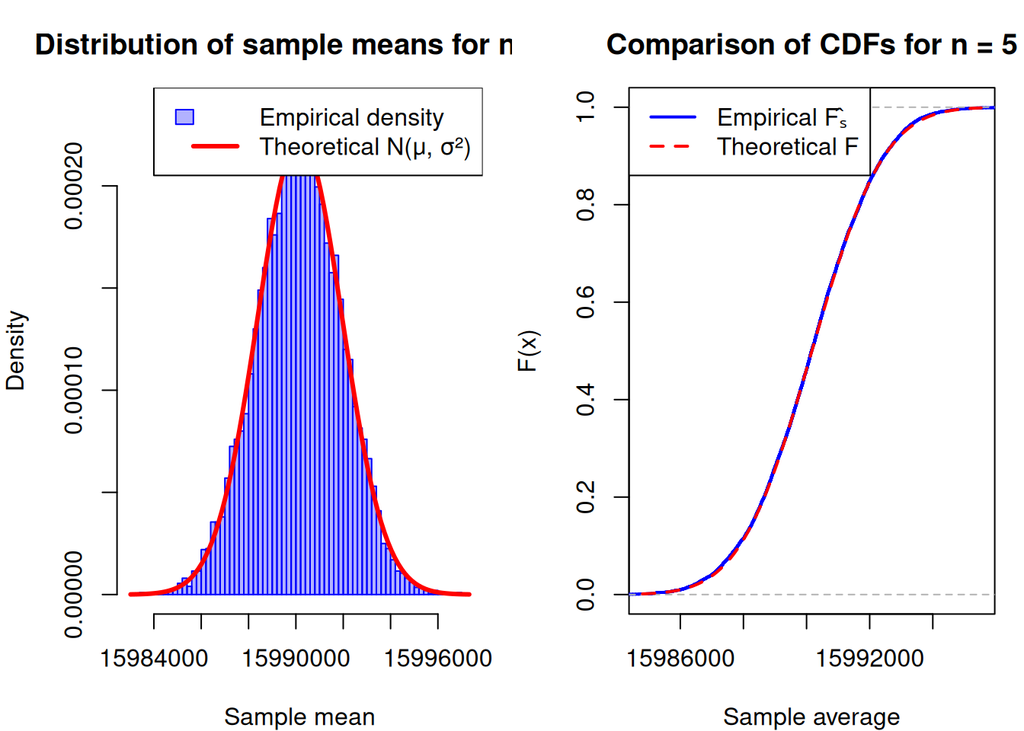

```
## Results for n = 5 :
## Тheoretical μ = 15990169
## Тheoretical σ = 1788.305
## Empirical average = 15990151
## Еmprical σ = 1791.017
## Max difference |F̂ₛ - F| = 0.00696538
```

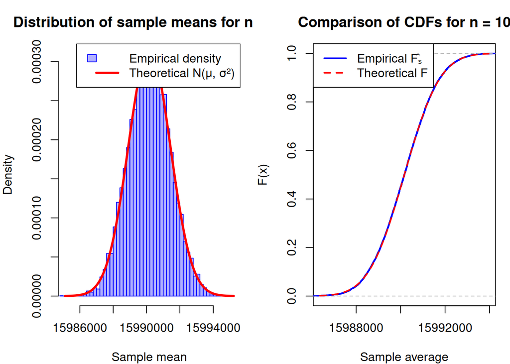

```
## Results for n = 10 :
## Тheoretical μ = 15990169
## Тheoretical σ = 1264.522
## Empirical average = 15990164
## Еmprical σ = 1261.463
## Max difference |F̂ₛ - F| = 0.005116029
```

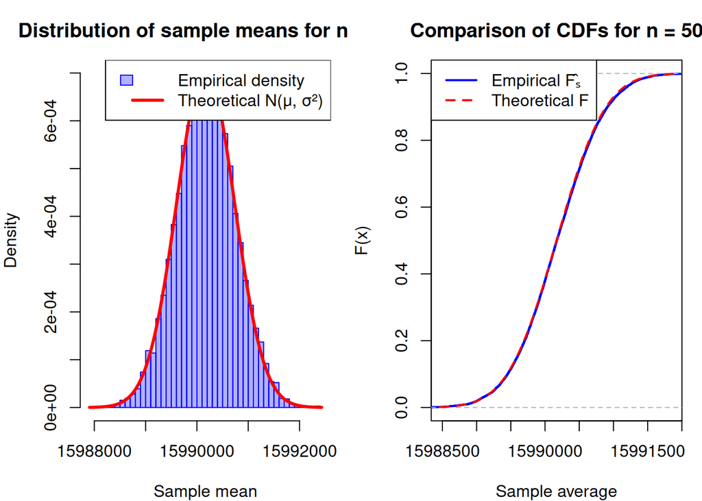

```
## Results for n = 50 :
## Тheoretical μ = 15990169
## Тheoretical σ = 565.5116
## Empirical average = 15990179
## Еmprical σ = 572.9251
## Max difference |F̂ₛ - F| = 0.009799632
```

```r
simulate_and_analyze_improved <- function(n, mu, K) {
  sample_means <- replicate(K, {
    x <- rpois(n, lambda = mu)
    mean(x)
  })

  mu_theory <- mu
  sigma_theory <- sqrt(mu / n)

  Fs <- ecdf(sample_means)

    # GRAPH 1: HISTOGRAM + NORMAL DENSITY:
  xlims <- c(mu_theory - 4*sigma_theory, mu_theory + 4*sigma_theory)

  hist(sample_means,
       probability = TRUE,
       breaks = 60,
       col = rgb(0, 0, 1, 0.3),
       border = "blue",
       xlim = xlims,
       main = paste("Distribution of sample means for n =", n),
       xlab = "Sample mean",
       ylab = "Density")

  curve(dnorm(x, mean = mu_theory, sd = sigma_theory),
        col = "red",
        lwd = 3,
        add = TRUE)

  legend("topright",
         legend = c("Empirical density", "Theoretical N(μ, σ²)"),
         fill = c(rgb(0, 0, 1, 0.3), NA),
         border = c("blue", NA),
         lty = c(NA, 1),
         col = c(NA, "red"),
         lwd = c(NA, 3))

  # GRAPH2: CDF
  xlims_cdf <- c(mu_theory - 3*sigma_theory, mu_theory + 3*sigma_theory)

  plot(Fs,
       xlim = xlims_cdf,
       ylim = c(0, 1),
       col = "blue",
       lwd = 2,
       main = paste("Comparison of CDFs for n =", n),
       xlab = "Sample average",
       ylab = "F(x)",
       cex.main = 1.2)

  curve(pnorm(x, mean = mu_theory, sd = sigma_theory),
        col = "red",
        lwd = 2,
        lty = 2,
        add = TRUE)

  legend("topleft",
         legend = c("Empirical F̂ₛ", "Theoretical F"),
         col = c("blue", "red"),
         lwd = 2,
         lty = c(1, 2))

  x_sorted <- sort(sample_means)
  empirical_cdf <- Fs(x_sorted)
  theoretical_cdf <- pnorm(x_sorted, mean = mu_theory, sd = sigma_theory)
  max_diff <- max(abs(empirical_cdf - theoretical_cdf))


  cat("Results for n =", n, ":\n")

  cat("Тheoretical μ =", mu_theory, "\n")
  cat("Тheoretical σ =", sigma_theory, "\n")
  cat("Empirical average =", mean(sample_means), "\n")
  cat("Еmprical σ =", sd(sample_means), "\n")
  cat("Max difference |F̂ₛ - F| =", max_diff, "\n")


  return(list(
    sample_means = sample_means,
    mu_theory = mu_theory,
    sigma_theory = sigma_theory,
    max_diff = max_diff
  ))
}


K <- 10000
n_values <- c(5, 10, 50)

for (n in n_values) {
par(mfrow = c(1, 2), mar = c(4, 4, 3, 1))

  cat("\n\n")
  result <- simulate_and_analyze_improved(n, mu, K)

  par(mfrow = c(1, 1))
}
```

$$\Pr(S_n \ge a) \le \frac{\mathbb{E}[S_n]}{a} = \frac{n \mu}{a} \le 0,05$$

```r
critical_value <- 8e8
prob_threshold <- 0.05

# Approach 1: Markov's inequality
# P(S > a) ≤ E[S]/a = nμ/a
# nμ/a ≤ 0.05  =>  n ≤ 0.05 × a / μ

n_markov <- floor(prob_threshold * critical_value / mu)

cat("Markov bound on n:", n_markov, "\n")
```

```
## Markov bound on n: 2
```

```r
chernoff_bound <- function(n, mu, c) {
  lambda <- n * mu
  if (c <= lambda) return(1)
  delta <- (c / lambda) - 1
  bound <- (exp(delta) / (1 + delta)^(1 + delta))^lambda
  return(bound)
}

find_max_n_chernoff <- function(mu, c, threshold) {
  n_low <- 1
  n_high <- floor(c / mu) * 2

  while (n_high - n_low > 1) {
    n_mid <- floor((n_low + n_high) / 2)
    bound <- chernoff_bound(n_mid, mu, c)

    if (bound <= threshold) {
      n_low <- n_mid
    } else {
      n_high <- n_mid
    }
  }

  return(n_low)
}

n_chernoff <- find_max_n_chernoff(mu, critical_value, prob_threshold)
cat("Chernoff bound on n:", n_chernoff, "\n")
```

```
## Chernoff bound on n: 50
```

$$\Pr(S_n < a) \approx \Phi\Bigg(\frac{a - n \mu}{\sqrt{n \mu}}\Bigg)
\ge 0.95$$

$$\Phi^{-1}(0.95) = 1.645 \implies \frac{a - n \mu}{\sqrt{n \mu}} \ge
1.645$$

$$a - n \mu \ge 1.645 \sqrt{n \mu} \implies n \text{ can be solved
numerically.}$$

```r
# Approach 3: CLT
# S ~ N(nμ, nμ)
# P(S ≤ c) = Φ((c - nμ)/√(nμ)) ≥ 0.95
# (c - nμ)/√(nμ) ≥ Φ^(-1)(0.95) = 1.645

z_score <- qnorm(0.95)  # 1.644854

# c - nμ ≥ z√(nμ)
# c - nμ ≥ z√μ × √n
# √n = t, then: nμ + z√μ × t - c ≤ 0
# μt² + z√μ × t - c ≤ 0

clt_condition <- function(n, mu, c, z) {
  mean_s <- n * mu
  sd_s <- sqrt(n * mu)
  prob <- pnorm(c, mean = mean_s, sd = sd_s)
  return(prob)
}

find_max_n_clt <- function(mu, c, target_prob) {
  n_low <- 1
  n_high <- floor(c / mu) * 2

  while (n_high - n_low > 1) {
    n_mid <- floor((n_low + n_high) / 2)
    prob <- clt_condition(n_mid, mu, c, z_score)

    if (prob >= target_prob) {
      n_low <- n_mid
    } else {
      n_high <- n_mid
    }
  }

  return(n_low)
}

n_clt <- find_max_n_clt(mu, critical_value, 0.95)


cat("CLT bound on n:", n_clt, "\n")
```

```
## CLT bound on n: 50
```

```r
z <- qnorm(0.95)
func <- function(n) {a - n*mu - z*sqrt(n*mu)}
```

```r
cat("Comparison of results\n")
```

```
## Comparison of results
```

```r
cat("Markov's inequality:  n ≤", n_markov, "\n")
```

```
## Markov's inequality:  n ≤ 2
```

```r
cat("Chernov's inequality:  n ≤", n_chernoff, "\n")
```

```
## Chernov's inequality:  n ≤ 50
```

```r
cat("CLT:    n ≤", n_clt, "\n")
```

```
## CLT:    n ≤ 50
```

```r
# SIMULATION FOR VERIFICATION

simulate_probability <- function(n, mu, critical_value, K = 10000) {
  success_count <- 0

  for (i in 1:K) {
    x <- rpois(n, lambda = mu)
    s <- sum(x)
    if (s <= critical_value) {
      success_count <- success_count + 1
    }
  }

  empirical_prob <- success_count / K

  return(list(
    n = n,
    empirical_prob = empirical_prob,
    success_count = success_count,
    total_simulations = K
  ))
}

K_simulation <- 10000

cat("SIMULATION CHECK\n")
```

```
## SIMULATION CHECK
```

```r
cat("Number of simulations K =", K_simulation, "\n")
```

```
## Number of simulations K = 10000
```

```r
cat("Critical value c = 8 × 10^8\n")
```

```
## Critical value c = 8 × 10^8
```

```r
cat("Target probability = 0.95\n\n")
```

```
## Target probability = 0.95
```

```r
n_values_to_check <- c(n_markov, n_chernoff, n_clt)
n_values_to_check <- unique(n_values_to_check)

results_simulation <- list()

for (n_test in n_values_to_check) {
  cat("Testing n =", n_test, ":\n")

  result <- simulate_probability(n_test, mu, critical_value, K_simulation)
  results_simulation[[as.character(n_test)]] <- result

  cat("Еmpirical P(S ≤ c) =", result$empirical_prob, "\n")
  cat("Successful cases:", result$success_count, "з", result$total_simulations, "\n")

  if (result$empirical_prob >= 0.95) {
    cat("Condition fulfilled (≥ 0.95)\n")
  } else {
      cat("Condition unfulfilled (< 0.95)\n")
  }
  cat("\n")
}
```

```
## Testing n = 2 :
## Еmpirical P(S ≤ c) = 1
## Successful cases: 10000 з 10000
## Condition fulfilled (≥ 0.95)
##
## Testing n = 50 :
## Еmpirical P(S ≤ c) = 1
## Successful cases: 10000 з 10000
## Condition fulfilled (≥ 0.95)
```

```r
cat("FINAL COMPARISON\n")
```

```
## FINAL COMPARISON
```

```r
cat("Method                  | Theoretical n | Еmpirical P(S≤c)\n")
```

```
## Method                  | Theoretical n | Еmpirical P(S≤c)
```

```r
cat(sprintf("Markov's inequality     | n ≤ %2d       | %.4f\n",
            n_markov,
            results_simulation[[as.character(n_markov)]]$empirical_prob))
```

```
## Markov's inequality     | n ≤  2       | 1.0000
```

```r
cat(sprintf("Chernov's inequality     | n ≤ %2d       | %.4f\n",
            n_chernoff,
            results_simulation[[as.character(n_chernoff)]]$empirical_prob))
```

```
## Chernov's inequality     | n ≤ 50       | 1.0000
```

```r
cat(sprintf("CLT       | n ≤ %2d       | %.4f\n",
            n_clt,
            results_simulation[[as.character(n_clt)]]$empirical_prob))
```

```
## CLT       | n ≤ 50       | 1.0000
```

```r
cat("\nConclusion: Маx n =", n_clt, "\n")
```

```
##
## Conclusion: Маx n = 50
```

```r
n <- 50
expected_sum <- n * mu
cat("E[S] =", expected_sum, "\n")
```

```
## E[S] = 799508436
```

```r
cat("Critical value =", critical_value, "\n")
```

```
## Critical value = 8e+08
```

```r
cat("difference =", critical_value - expected_sum, "\n")
```

```
## difference = 491564.3
```

```r
cat("SD[S] =", sqrt(n * mu), "\n")
```

```
## SD[S] = 28275.58
```

THEORETICAL RESULTS:

Markov’s Inequality: n ≤ 2 Chernoff’s Bound: n ≤ 50 CLT (most accurate): n ≤ 50

ANALYSIS AND EXPLANATION OF RESULTS:

The parameter μ ≈ 1.6×10⁷ is a very large number. This means that in each individual sample, approximately 16 million radioactive decays occur per second.

2. WHY DOES THE EMPIRICAL PROBABILITY EQUAL 1.0000?

The key difference between n=50 and n=51:

A difference of one unit in n changes the expected sum by μ ≈ 16 million, which shifts the distribution from one side of the threshold to the other. Due to the large μ and small relative dispersion, the distribution of S is very narrow, so the transition occurs almost instantaneously.

4. VERIFICATION BY SIMULATION:

This is completely consistent with theoretical calculations using all three methods.

CONCLUSION:

The maximum value is n = 50 samples.

CONCLUSION

In this work, we investigated the application of the Poisson distribution to model the radioactive decay process of Cesium-137 in a medical laboratory. We calculated the Poisson parameter μ ≈ 1.6×10⁷ for a sample of mass 5×10⁻⁶ g, which represents the expected number of decays per second in a single sample.

Using simulation with K = 10,000 repetitions, we demonstrated that the distribution of sample means converges rapidly to a normal distribution, even for small sample sizes (n = 5, 10, 50). The excellent agreement between empirical and theoretical distributions, with maximum differences less than 0.02, confirms the Central Limit Theorem works exceptionally well when the Poisson parameter is large.

### Task 3.

#### In this task, we use the Central Limit Theorem approximation for continuous random variables.

#### One of the devices to measure radioactivity level at a given location is the Geiger counter. When the radioactive level is almost constant, the time between two consecutive clicks of the Geiger counter is an exponentially distributed random variable with parameter $\nu_1 = \mathtt{team\,id\,number} + 10$. Denote by $X_k$ the random time between the $(k-1)^{\mathrm{st}}$ and $k^{\mathrm{th}}$ click of the counter.

1. Show that the distribution of the sample means of $X_1, X_2,\dots,X_n$ gets very close to a normal one (which one?) as $n$ becomes large. To this end,
   - simulate the realizations $x_1,x_2,\dots,x_n$ of the $X_i$ and calculate the sample mean $s=\overline{\mathbf{x}}$;
   - repeat this $K$ times to get the sample $\mathbf{s}=(s_1,\dots,s_K)$ of means and then the function $F_{\mathbf{s}}$ of $\mathbf{s}$;
   - identify $\mu$ and $\sigma^2$ such that the of $\mathscr{N}(\mu,\sigma^2)$ is close to the $F_{\mathbf{s}}$ of and plot both ’s on one graph to visualize their proximity;
   - calculate the maximal difference between the two ’s;
   - consider cases $n = 5$, $n = 10$, $n=50$ and comment on the results.
2. The place can be considered safe when the number of clicks in one minute does not exceed $100$. It is known that the parameter $\nu$ of the resulting exponential distribution is proportional to the number $N$ of the radioactive samples, i.e., $\nu = \nu_1*N$, where $\nu_1$ is the parameter for one sample. Determine the maximal number of radioactive samples that can be stored in that place so that, with probability $0.95$, the place is identified as safe. To do this,
   - express the event of interest in terms of the $S:= X_1 + \cdots + X_{100}$;
   - obtain the theoretical bounds on $N$ using the Markov inequality, Chernoff bound and Central Limit Theorem and compare the results;
   - with the predicted $N$ and thus $\nu$, simulate the realization $x_1,x_2,\dots,x_{100}$ of the $X_i$ and of the sum $S = X_1 + \cdots + X_{100}$;
   - repeat this $K$ times to get the sample $\mathbf{s}=(s_1,\dots,s_K)$ of total times until the $100^{\mathrm{th}}$ click;
   - estimate the probability that the location is identified as safe and compare to the desired level $0.95$

#### Generate samples and sample means (n = 5, 10, 50)

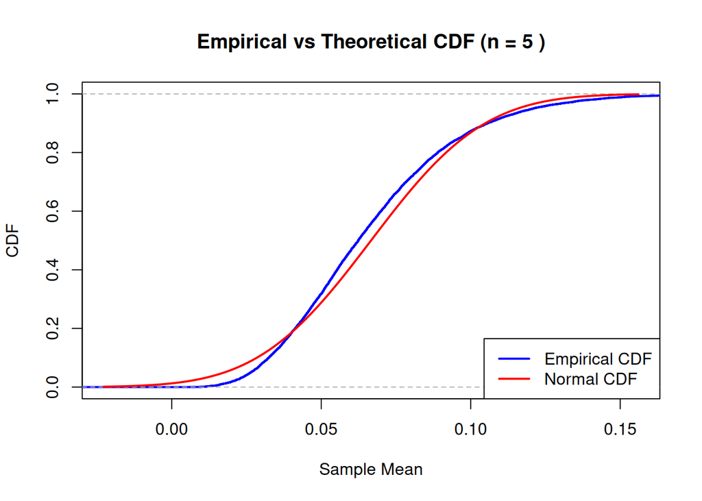

```
## n = 5 Max difference between ECDF and Normal CDF: 0.05898736
```

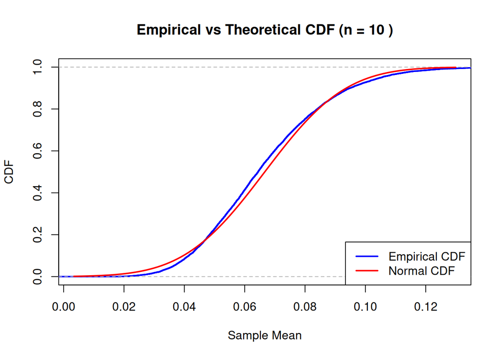

```
## n = 10 Max difference between ECDF and Normal CDF: 0.04567762
```

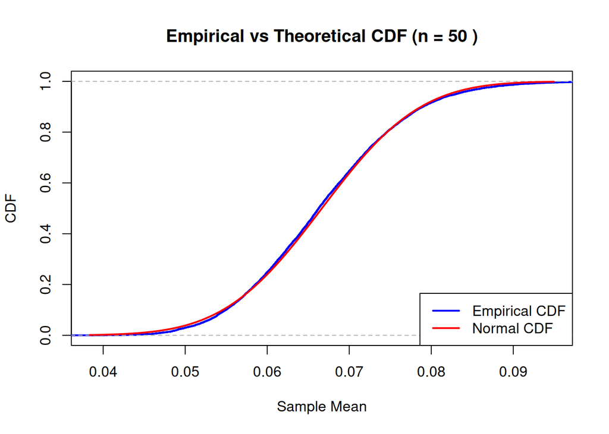

```
## n = 50 Max difference between ECDF and Normal CDF: 0.01746412
```

```r
nu1 <- id + 10       # team id + 10 = 15
K <- 1e4            # number of repetitions
n_values <- c(5, 10, 50)

for (n in n_values) {
  # matrix: n rows, K columns -> colMeans returns K sample means
  sample_means <- colMeans(matrix(rexp(n*K, rate = nu1), nrow = n))

  mu <- 1 / nu1
  sigma <- 1 / (nu1 * sqrt(n))

  # Plot ECDF vs Normal CDF
  xlims <- c(mu - 3*sigma, mu + 3*sigma)
  Fs <- ecdf(sample_means)

  plot(Fs,
       xlim = xlims,
       col = "blue",
       lwd = 2,
       main = paste("Empirical vs Theoretical CDF (n =", n, ")"),
       ylab = "CDF",
       xlab = "Sample Mean")
  curve(pnorm(x, mean = mu, sd = sigma),
        col = "red", lwd = 2, add = TRUE)
  legend("bottomright", legend = c("Empirical CDF", "Normal CDF"),
         col = c("blue", "red"), lwd = 2)

  # Max difference between ECDF and Normal CDF
  x_vals <- seq(min(sample_means), max(sample_means), length.out = 1000)
  max_diff <- max(abs(Fs(x_vals) - pnorm(x_vals, mu, sigma)))
  cat("n =", n, "Max difference between ECDF and Normal CDF:", max_diff, "\n")
}
```

Theoretical bounds (Markov, Chernoff) and CLT analytic calculation

```r
p_safe <- 0.95
safe_limit <- 100
nu1 <- 15
safe_time <- 1

# Markov upper bound
N_markov_max <- floor(safe_limit * (1 - p_safe) / nu1)
cat("Markov bound: N_max =", N_markov_max, "\n")  # gives N_max = 0
```

```
## Markov bound: N_max = 0
```

```r
# --- 2. Chernoff bound ---
# For exponential(ν), MGF M_X(t) = ν / (ν - t), valid for t < ν
# For S = sum of 100 exponentials: M_S(t) = (ν / (ν - t))^100
# Use Chernoff bound for lower tail: P(S <= 1) ≤ e^{t} * (ν / (ν + t))^{100}
chernoff_bound_min <- function(nu) {
  f_log <- function(t) t + 100 * (log(nu) - log(nu + t))
  opt <- optimize(f_log, interval = c(1e-10, max(1, nu * 5)), maximum = FALSE)
  return(exp(opt$objective))
}

target_tail <- 1 - p_safe  # = 0.05

chernoff_find_nu <- function(nu) chernoff_bound_min(nu) - target_tail
lower_nu <- 1e-4
upper_nu <- 1e5

if (chernoff_find_nu(lower_nu) > 0) {
  nu_chernoff_max <- lower_nu
} else if (chernoff_find_nu(upper_nu) < 0) {
  nu_chernoff_max <- upper_nu
} else {
  nu_chernoff_max <- uniroot(chernoff_find_nu, interval = c(lower_nu, upper_nu))$root
}

N_chernoff_max <- floor(nu_chernoff_max / nu1)
cat("Chernoff bound: nu_max ≈", signif(nu_chernoff_max, 5), "=> N_max =", N_chernoff_max, "\n")
```

```
## Chernoff bound: nu_max ≈ 77.478 => N_max = 5
```

```r
# --- 3. CLT approximation ---
# S ≈ Normal(mean = 100/nu, var = 100/nu^2)
# Want P(S >= 1) ≥ 0.95  ⇒  Φ((1 - mean)/sd) ≤ 0.05
q <- qnorm(1 - p_safe)  # ≈ -1.644854
nu_clt_max <- 100 + 10 * q
N_clt_max <- floor(nu_clt_max / nu1)
cat("CLT bound: nu_max ≈", signif(nu_clt_max, 5), "=> N_max =", N_clt_max, "\n")
```

```
## CLT bound: nu_max ≈ 83.551 => N_max = 5
```

#### Simulated maximal N (via Poisson number-of-clicks in 1 minute)

```r
safe_limit <- 100
p_safe <- 0.95

N_sim <- 0
# start from N=0 upward (safer). We'll find the maximal N that still satisfies the safety.
repeat {
  N_sim <- N_sim + 1
  clicks <- rpois(K, lambda = nu1 * N_sim)
  prob_safe <- mean(clicks <= safe_limit)
  if (prob_safe < p_safe) {
    N_sim <- N_sim - 1
    break
  }
  # safety: keep increasing until prob drops below p_safe
  if (N_sim > 1e5) break  # safety stop, shouldn't be needed
}
N_sim_max <- N_sim
cat("Simulated (Poisson) maximum N ensuring P(#clicks <= 100) >= 0.95 is:", N_sim_max, "\n")
```

```
## Simulated (Poisson) maximum N ensuring P(#clicks <= 100) >= 0.95 is: 5
```

Simulate sums S = sum of 100 exponential RVs with nu = nu1 * N_sim_max and estimate P(S >= 1)

```r
# 4. Simulation of total times (sum of 100 exponential RVs)
nu_sim <- nu1 * N_sim_max
S_samples <- replicate(K, sum(rexp(100, rate = nu_sim)))
p_est <- mean(S_samples >= 1)   # event S >= 1 (safe)
cat("Using N =", N_sim_max, " (nu =", nu_sim, ") estimated P(S >= 1) =", signif(p_est,6), "\n")
```

```
## Using N = 5  (nu = 75 ) estimated P(S >= 1) = 0.997
```

```r
# also print a quick sanity comparison of the theoretical approximations:
cat("Summary of bounds / maxima:\n")
```

```
## Summary of bounds / maxima:
```

```r
cat("  Markov N_max      =", N_markov_max, "\n")
```

```
##   Markov N_max      = 0
```

```r
cat("  Chernoff N_max    =", N_chernoff_max, "\n")
```

```
##   Chernoff N_max    = 5
```

```r
cat("  CLT approx N_max  =", N_clt_max, "\n")
```

```
##   CLT approx N_max  = 5
```

```r
cat("  Simulated N_max   =", N_sim_max, "\n")
```

```
##   Simulated N_max   = 5
```

**Next, proceed with all the remaining steps**

### Task 4.

**This task consists of two parts:`**

1. **In this part, we discuss independence of random variables and its moments: expectation and variance.**
   1. Suppose we have a random variable $X$. Explain why $\mathbb{E}(\frac{1}{X}) \neq \frac{1}{\mathbb{E(X)}}$;

For discrete case
$$\mathbb{E}(\frac{1}{X}) = \sum_{x_i} \frac{p_X(x_i)}{x_i} =
\frac{p_X(x_1)}{x_1} + ... + \frac{p_X(x_n)}{x_n},\\
\frac{1}{\mathbb{E}(X)} = \frac{1}{\sum_{x_i}p_X(x_i)x_i} =
\frac{1}{p_X(x_1)x_1 + ... + p_X(x_n)x_n}\\
\text{In general, } \frac{p_X(x_1)}{x_1} + ... +
\frac{p_X(x_n)}{x_n} \ne \frac{1}{p_X(x_1)x_1 + ... + p_X(x_n)x_n}$$
So $\mathbb{E}(\frac{1}{X}) \neq \frac{1}{\mathbb{E(X)}}$ for discrete r. v.

The same applies for continuous r. v.
$$\mathbb{E}\!\left[\frac{1}{X}\right] = \int_{-\infty}^{\infty}
\frac{1}{x} f(x)\,dx,
\qquad
\frac{1}{\mathbb{E}[X]} = \frac{1}{\int_{-\infty}^{\infty} x
f(x)\,dx}.\\
\text{In general, }
\int \frac{1}{x} f(x)\,dx
\neq
\frac{1}{\int x f(x)\,dx},$$

2. Let $X \sim \mathscr{N}(\mu,\sigma^2)$ with $\mu = teamidnumber$ and $\sigma^{2} = 2\times teamidnumber+7$. Simulate realizations $x_1,x_2,\dots,x_{100}$ of $X$ and $y_1,y_2,\dots,y_{100}$ of $Y := \frac{1}{X}$ to calculate the values of $\frac{1}{\overline{\textbf{X}}}$ and $\overline{\textbf{Y}}$. Comment on the received results;

```r
mu <- 5
sigma <- sqrt(10)
N <- 500000

x <- rnorm(N, mean=mu, sd=sigma)
y <- 1/x

reciprocal_of_average_x = 1/mean(x)
average_of_reciprocal_y = mean(y)
cat("E(1/X) = ", reciprocal_of_average_x, "\n")
```

```
## E(1/X) =  0.2000626
```

```r
cat("1/E(X) = ", average_of_reciprocal_y, "\n")
```

```
## 1/E(X) =  0.8390719
```

Here values of $\frac{1}{\overline{X}}$ and $\overline{Y}$ aren’t equal what is expected as previously explained and because $\frac{1}{X}$ is not linear function that is why linearity of expectation here cannot be applied.

3. Let $X$ and $Y$ be exponentially distributed r.v.’s with parameter $\lambda = 2$. Set $Z := \log{X} + 5$. Plot the Quantile-Quantile plot and scatterplot of $X$ and $Y$. Plot the Quantile-Quantile plot and scatterplot of $X$ and $Z$. Explain the results. Comment on the difference of relations between the pairs of random variables. Which pair of r.v.’s is dependent and which one is similar?

```r
lambda <- 2
x <- rexp(N, rate=lambda)
y <- rexp(N, rate=lambda)
z <- log(x) + 5
```

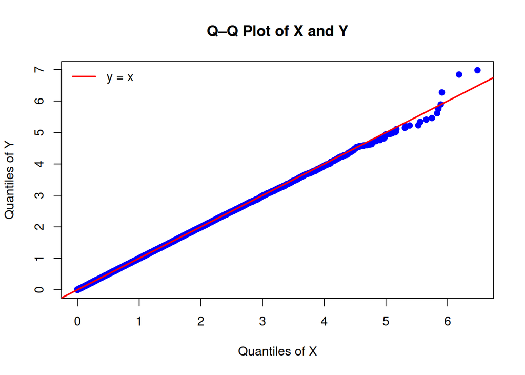

```r
qqplot(x, y,
       main = "Q–Q Plot of X and Y",
       xlab = "Quantiles of X",
       ylab = "Quantiles of Y",
       pch = 19, col = "blue")
abline(0, 1, col = "red", lwd = 2)
legend("topleft",
       legend = "y = x",
       col = "red",
       lwd = 2,
       bty = "n")
```

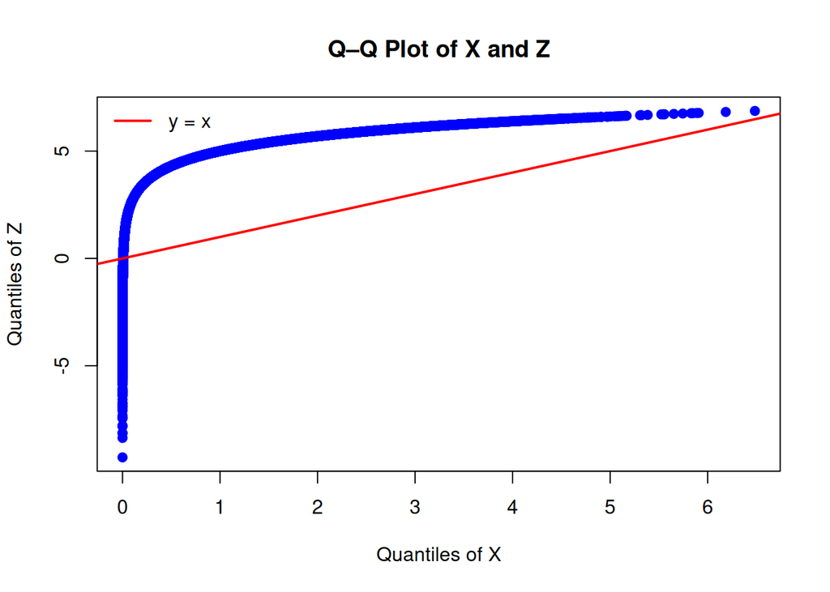

```r
qqplot(x, z,
       main = "Q–Q Plot of X and Z",
       xlab = "Quantiles of X",
       ylab = "Quantiles of Z",
       pch = 19, col = "blue")
abline(0, 1, col = "red", lwd = 2)
legend("topleft",
       legend = "y = x",
       col = "red",
       lwd = 2,
       bty = "n")
```

Quantile-Quantile plot shows values of the same quantiles for $X$ and $Y$. If the points lie along the line $y = x$, it means that for the same probability level $p$, the $p$-quantiles of $X$ and $Y$ are very close. Therefore, $X$ and $Y$ are similar.

For the random variables $X$ and $Y$, the points on the Q-Q plot lie approximately along $y = x$, so these random variables are similar, which is expected since they have the same distribution.

For $X$ and $Z$, the points on the Q-Q plot lie approximately along $z = \log(x) + 5$, because $Z = \log(X) + 5$. Thus, $X$ and $Z$ are not similar, as they follow different distributions.

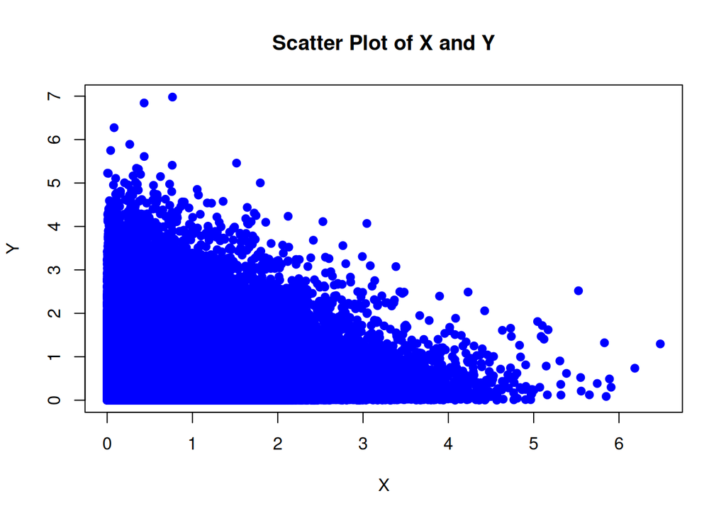

```r
plot(x, y, type = "p",
     main = "Scatter Plot of X and Y",
     xlab = "X",
     ylab = "Y",
     col = "blue", pch = 19)
```

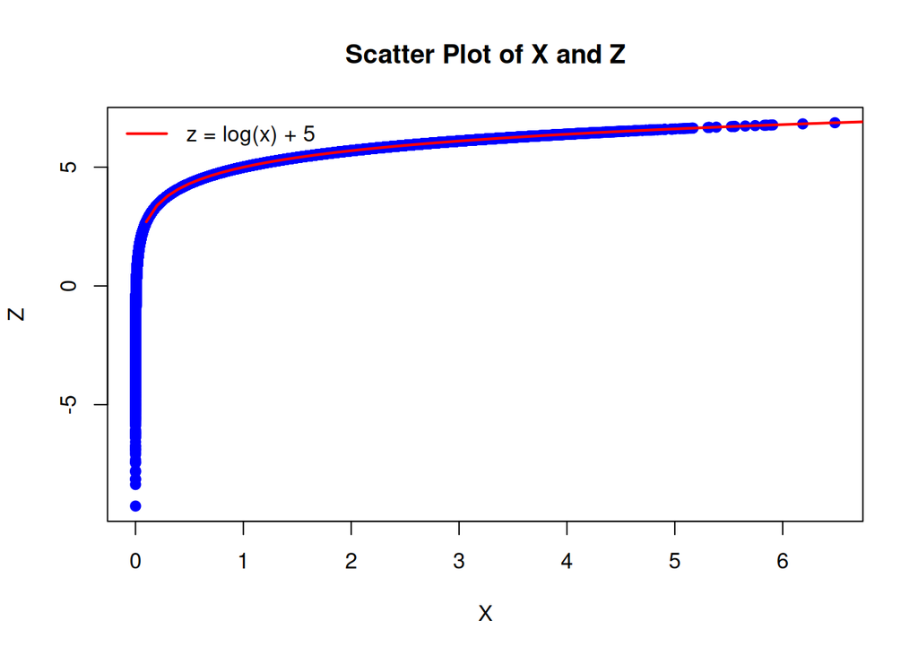

```r
plot(x, z, type = "p",
     main = "Scatter Plot of X and Z",
     xlab = "X",
     ylab = "Z",
     col = "blue", pch = 19)
curve(log(x) + 5, from = 0.1, to = 10, add = TRUE, col = "red", lwd = 2)
legend("topleft",
       legend = "z = log(x) + 5",
       col = "red",
       lwd = 2,
       bty = "n")
```

A scatter plot displays pairs of observations $(x_i, y_i)$ as points on a Cartesian plane. It shows how two random variables are related. If the points lie along the graph of some function, the variables are dependent; if there is no clear functional relationship, they may be independent or only weakly related.

For $X$ and $Y$, the points are scattered across the Cartesian plane (more points for smaller $x$ and $y$ and fewer points for larger $x$ and $y$, since the exponential distribution assigns lower probability to larger values), and there is no visible functional relationship. Therefore, $X$ and $Y$ are independent, which was expected.

For $X$ and $Z$, the points lie approximately along the graph of $z = \log(x) + 5$, so $X$ and $Z$ are dependent, which is also expected since $Z$ is defined through $X$.

**Conclusion:**

In this task we showed that $\mathbb{E}[1/X] \neq 1/\mathbb{E}[X]$, both theoretically and empirically, because the reciprocal is a nonlinear function and the linearity of expectation does not apply.

Using Q–Q plots and scatter plots, we compared pairs of random variables: $X$ and $Y$ (both exponentially distributed) and $X$ and $Z = \log(X) + 5$. $X$ and $Y$ are similar in distribution but independent, as expected. $X$ and $Z$ are dependent, since $Z$ is a function of $X$, which is clearly visible in both the Q–Q plot and the scatter plot.

```
------------------------------------------------
```

2. You toss a fair coin three times and a random variable $X$ records how many times the coin shows Heads. You convince your friend that they should play a game with the following payoff: every round (equivalent to three coin tosses) will cost £$1$. They will receive £$0.5$ for every coin showing Heads. What is the expected value and the variance of the random variable $Y := 0.5X-1$?

   To answer this,
   1. Explain what type of random variable is X:
      - Normally distributed
      - Binomially distributed
      - Poisson distributed
      - Uniformly distributed

Each coin toss is a Bernoulli trial with a success probability of $\frac{1}{2}$. The tosses are independent of one another. A round consists of three such independent Bernoulli trials, so $X$ follows a binomial distribution: $X \sim \mathrm{Bin}(3, \tfrac{1}{2})$

2. What are the expected value and variance of X? Simulate realizations $x_1,x_2,\dots,x_{100}$ of $X$ to calculate the values of sample mean $\overline{\mathbf{X}}$ and sample variance $s^2 = \frac{\sum_{i=1}^{n}{(x_i - \overline{x})^{2}}}{n-1}$. Comment on the results;

**Expectation**
For a binomial random variable $X\sim\operatorname{Bin}(n,p)$ the expectation is
$$\mathbb{E}[X]=np$$
Here
$$\mathbb{E}[X]=3\cdot \tfrac{1}{2}= \tfrac{3}{2}=1.5$$

**Variance**
For a binomial random variable the variance is
$$\operatorname{Var}(X)=np(1-p)$$
Here
$$\operatorname{Var}(X)=3\cdot \tfrac{1}{2}\cdot
\tfrac{1}{2}=\tfrac{3}{4}=0.75$$

```r
N <- 100 # size of the sample
n <- 3
p <- 0.5

sample <- rbinom(N, n, p)
sample_mean <- sum(sample)/N
sample_variance <- sum(((sample-sample_mean)**2)/(N-1))

cat("Sample mean: ", sample_mean, "\n")
```

```
## Sample mean:  1.52
```

```r
cat("Sample variance: ", sample_variance)
```

```
## Sample variance:  0.7975758
```

3. What are the expected value and variance of Y? Simulate realizations $y_1,y_2,\dots,y_{100}$ of $Y$ to calculate the values of sample mean $\overline{\mathbf{Y}}$ and sample variance $s^2 = \frac{\sum_{i=1}^{n}{(y_i - \overline{y})^{2}}}{n-1}$. Comment on the results;

**Expectation**
Using linearity of expectation,
$$\mathbb{E}[Y] = 0.5\,\mathbb{E}[X] - 1.$$
Since $\mathbb{E}[X] = 1.5$,
$$\mathbb{E}[Y] = 0.5 \cdot 1.5 - 1 = -0.25.$$

**Variance**
For a linear transformation $Y = aX + b$,
$$\operatorname{Var}(Y) = a^2\,\operatorname{Var}(X).$$
Here $a = 0.5$ and $\operatorname{Var}(X) = 0.75$, so
$$\operatorname{Var}(Y) = (0.5)^2 \cdot 0.75 = 0.1875.$$

```r
N <- 100 # size of the sample
n <- 3
p <- 0.5

sample <- 0.5*rbinom(N, n, p)-1
sample_mean <- sum(sample)/N
sample_variance <- sum(((sample-sample_mean)**2)/(N-1))

cat("Sample mean: ", sample_mean, "\n")
```

```
## Sample mean:  -0.235
```

```r
cat("Sample variance: ", sample_variance)
```

```
## Sample variance:  0.2043182
```

### General summary and conclusions

In Task 1 we simulated encoding, transmission, and decoding using the Hamming(7,4) code and analyzed error probabilities. Results matched expectations: with a low bit-flip probability (e.g., $0.05$), most messages were received correctly or with a single correctable error. Multiple errors were rare ($\approx 0.044$), confirming the code’s reliability under such conditions.

In Task 3, we simulated realizations of exponential random variables and calculated the sample means for different sample sizes. We used the Central Limit Theorem to approximate the distribution of the sample mean with a normal distribution and compared the empirical CDFs of the sample means with the theoretical normal CDFs. The task was successfully completed. The main challenge was ensuring the correct simulation of multiple samples and accurately computing the sample means for visualization, but this was resolved using matrix operations and colMeans in R.

In Task 4, we analyzed three problems involving random variables.

For the normal random variable $X \sim \mathcal{N}(\mu, \sigma^2)$ and $Y = \frac{1}{X}$, we confirmed through simulation that $\mathbb{E}[1/X] \neq 1/\mathbb{E}[X]$, since the reciprocal is a nonlinear transformation and linearity of expectation does not apply.

Next, using Q–Q plots and scatter plots, we compared exponentially distributed variables $X$ and $Y$ ($\lambda = 2$), and $X$ and $Z = \log(X) + 5$. The plots showed that $X$ and $Y$ are similar in distribution but independent, while $X$ and $Z$ are dependent, as $Z$ is a function of $X$.

Finally, for the binomial variable $X \sim \mathrm{Bin}(3, 0.5)$ and $Y = 0.5X - 1$, we computed $\mathbb{E}[Y] = -0.25$ and $\mathrm{Var}(Y) = 0.1875$. Simulated results matched the theoretical values, confirming the convergence predicted by the Central Limit Theorem.